# Reproducible Research in Portfolio Selection

Majeed Simaan

January 4, 2023

# Overview

The following article builds on earlier codes from my [RPubs corner](https://rpubs.com/simaan84) and aims to replicate standard baseline portfolio research. By doing so, I hope the following initiative will encourage future reproducible research in portfolio selection. Specifically, the article builds on the empirical design conducted by Kan, Wang, and Zhou (2022), which is considered one of the typical frameworks used in the literature. For brevity, I refer to the paper/authors as KWZ. The analysis below replicates a subset of KWZ results, focusing on six public data sets and eleven portfolio rules. Nonetheless, the experiment can be generalized to additional data sets and portfolios. This generalization, however, presumes that the user is willing to take an extra effort to (1) add new data sets in the same format to the `data_list` object and (2) follow the logic behind the primary decision rule function and incorporate the rule as an additional vector of weights. I will discuss these adjustments as we proceed below.

# Libraries

In terms of implementation, I utilize seven libraries

```r
library(xts) # for time series manipulation
library(lubridate) # for date manipulation
library(parallel) # for parallel processing across data sets
library(readxl) # reading excel files to load data
library(ggplot2) # for visualization
library(zipfR) # needed for one of the decision rules
library(RiskPortfolios) # used for covariance matrix shrinkage

rm(list = ls())
```

The first is used for downloading data and working with time series. The second is for date manipulation and formatting. The third can be efficiently utilized on Linux machines to perform parallel computing using functional programming, e.g., working with `lapply`. The fourth one is to read xlsx formatted files, whereas the fifth is used for visualization. The last two are used in the implementation of the decision rules. Specifically, I utilize the library `zipfR` to implement the incomplete beta function as advised by KWZ. Finally, I employ the linear shrinkage for covariance matrices from the `RiskPortfolios` library.

# Getting the Data

KWZ rely on eight different data sources to evaluate different decision rules. Four of these come from Ken French’s website, two come from Robert Novy-Marx’s website, and the remaining are constructed from the CRSP database. In this article, I focus on the first six data sets which are publicly available: 1. 10 momentum portfolios (Momentum); January 1927 to December 2018 2. 25 Fama-French $5 \times 5$ size and book-to-market ranked portfolios (Size-B/M); from January 1927 to December 2018 3. 25 portfolios formed on operating profitability and investment (OP-Inv); from July 1963 to December 2018 4. 49 industry portfolios (Industry); from July 1969 to December 2018 5. 16 low turnover anomalies by Novy-Marx and Velikov (2016); from July 1963 to December 2013 6. 46 all turnover anomalies by Novy-Marx and Velikov (2016); from July 1973 to December 2013 (after dropping missing values)

With some minimal tweaking, we can download the Fama-French data in the following manner and put the four data sets into a single list as follows:

```r
# MOMETUM -  January 1927 to December 2018
FF_file <- "https://mba.tuck.dartmouth.edu/pages/faculty/ken.french/ftp/10_Portfolios_Prior_12_2_CSV.zip"
temp <- tempfile()
download.file(FF_file,temp)
unz_files <- unzip(temp)
ds <- read.csv(unz_files,skip = 10,stringsAsFactors = F)
flag_obs <- grep("Average Equal",ds[,1],ignore.case = T)
ds <- ds[1:(flag_obs-1),]
ds <- data.frame(apply(ds,2,as.numeric))
names(ds)[1] <- "date"
ds$date <- ds$date*100  + 1
ds$date <- ymd(ds$date)
ds$date <- ceiling_date(ds$date,"m") - 1
ds[,-1] <- ds[,-1]/100
ds <- ds[ds$date >= "1927-01-01",]
ds <- ds[ds$date <= "2018-12-31",]
ds1 <- ds

# 25BM - January 1927 to December 2018
FF_file <- "https://mba.tuck.dartmouth.edu/pages/faculty/ken.french/ftp/25_Portfolios_5x5_CSV.zip"
temp <- tempfile()
download.file(FF_file,temp)
unz_files <- unzip(temp)
ds <- read.csv(unz_files,skip = 15,stringsAsFactors = F)
flag_obs <- grep("Average Equal",ds[,1],ignore.case = T)
ds <- ds[1:(flag_obs-1),]
ds <- data.frame(apply(ds,2,as.numeric))
names(ds)[1] <- "date"
ds$date <- ds$date*100  + 1
ds$date <- ymd(ds$date)
ds$date <- ceiling_date(ds$date,"m") - 1
ds[,-1] <- ds[,-1]/100
ds <- ds[ds$date >= "1927-01-01",]
ds <- ds[ds$date <= "2018-12-31",]
ds2 <- ds

# 25OP-Inv July 1963 to December 2018
FF_file <- "https://mba.tuck.dartmouth.edu/pages/faculty/ken.french/ftp/25_Portfolios_OP_INV_5x5_CSV.zip"
temp <- tempfile()
download.file(FF_file,temp)
unz_files <- unzip(temp)
ds <- read.csv(unz_files,skip = 24,stringsAsFactors = F)
flag_obs <- grep("Average Equal",ds[,1],ignore.case = T)
ds <- ds[1:(flag_obs-1),]
ds <- data.frame(apply(ds,2,as.numeric))
names(ds)[1] <- "date"
ds$date <- ds$date*100  + 1
ds$date <- ymd(ds$date)
ds$date <- ceiling_date(ds$date,"m") - 1
ds[,-1] <- ds[,-1]/100
ds <- ds[ds$date >= "1963-07-01",]
ds <- ds[ds$date <= "2018-12-31",]
ds3 <- ds

# 49 Industry -  July 1969 to December 2018
FF_file <- "https://mba.tuck.dartmouth.edu/pages/faculty/ken.french/ftp/49_Industry_Portfolios_CSV.zip"
temp <- tempfile()
download.file(FF_file,temp)
unz_files <- unzip(temp)
ds <- read.csv(unz_files,skip = 11,stringsAsFactors = F)
flag_obs <- grep("Average Equal",ds[,1],ignore.case = T)
ds <- ds[1:(flag_obs-1),]
ds <- data.frame(apply(ds,2,as.numeric))
names(ds)[1] <- "date"
ds$date <- ds$date*100  + 1
ds$date <- ymd(ds$date)
ds$date <- ceiling_date(ds$date,"m") - 1
ds[,-1] <- ds[,-1]/100
ds <- ds[ds$date >= "1969-07-01",]
ds <- ds[ds$date <= "2018-12-31",]
ds4 <- ds
```

The other data sets can be downloaded from Robert Novy-Marx’s website and prepared efficiently. Note that the data covers different decile portfolios constructed based on different characteristics. Similar to KWZ, the first data set focuses on the low turnover anomaly strategies, which correspond to

```r
low_to_strat <- c("Size","Gross Profitability",
                  "Value","ValProf",
                  "Accruals","Asset Growth",
                  "Investment","Piotroski's F-score")

low_to_strat
```

```
[1] "Size"                "Gross Profitability" "Value"               "ValProf"
[5] "Accruals"            "Asset Growth"        "Investment"          "Piotroski's F-score"
```

The data can be downloaded and prepared in the following way:

```r
file.i <- "http://rnm.simon.rochester.edu/data_lib/ToAatTC/Simple_Strategies_Returns.xlsx"
temp <- tempfile()
download.file(file.i,temp)
ds_sheets_all <- sort(excel_sheets(temp))
ds_sheets <- ds_sheets_all[ds_sheets_all %in% low_to_strat]
NM_data_list <- list()
for (sheet_i in ds_sheets) {
  ds_i <- data.frame(read_xlsx(temp,sheet = sheet_i))
  ds_i <- ds_i[,c(1,2,ncol(ds_i))]
  names(ds_i)[-1] <- paste(sheet_i,names(ds_i)[-1],sep = "_")
  ds_i$date <- ds_i$Month
  ds_i$date <- ymd(ds_i$date*100 + 1)
  ds_i$date <- ceiling_date(ds_i$date,"m") - 1
  ds_i$Month <- NULL
  ds_i[,1:2] <- ds_i[,1:2]/100
  NM_data_list <- c(NM_data_list,list(ds_i))
}

NM_data_LT <- Reduce(merge,NM_data_list)
NM_data_LT <- na.omit(NM_data_LT)
```

Note that even though we consider eight characteristics, we have 16 portfolios. Similar to KWZ, I include both the long (top decile) and short (bottom decile) portfolios

```r
dim(NM_data_LT)
```

```
[1] 606  17
```

KWZ also considers all 23 anomalies corresponding to low, medium, and high turnover strategies. Same as above, we consider top and bottom deciles, resulting in 46 assets.

```r
mid_to_strat <- c("Net Issuance (rebal.-A)","Return-on-book equity","Failure Probability",
                  "ValMomProf","ValMom","Idiosyncratic Volatility",
                  "Momentum","PEAD (SUE)","PEAD (CAR3)")
high_to_start <- c("Industry Momentum","Industry Relative Reversals","High-frequency Combo",
                   "Short-run Reversals","Seasonality","IRR (Low Vol)")
all_to_start <- unique(sort(c(low_to_strat,mid_to_strat,high_to_start)))
length(all_to_start)
```

```
[1] 23
```

Let us repeat the same loop as before to create long and short portfolios:

```r
ds_sheets <- ds_sheets_all[ds_sheets_all %in% all_to_start]
NM_data_list <- list()
for (sheet_i in ds_sheets) {
  ds_i <- data.frame(read_xlsx(temp,sheet = sheet_i))
  ds_i <- ds_i[,c(1,2,ncol(ds_i))]
  names(ds_i)[-1] <- paste(sheet_i,names(ds_i)[-1],sep = "_")
  ds_i$date <- ds_i$Month
  ds_i$date <- ymd(ds_i$date*100 + 1)
  ds_i$date <- ceiling_date(ds_i$date,"m") - 1
  ds_i$Month <- NULL
  ds_i[,1:2] <- ds_i[,1:2]/100
  NM_data_list <- c(NM_data_list,list(ds_i))
}
```

[output not shown]

```r
NM_data_ALL <- Reduce(merge,NM_data_list)
NM_data_ALL <- na.omit(NM_data_ALL)
dim(NM_data_ALL)
```

```
[1] 486  47
```

Finally, we put the data altogether in a single list, so we can easily generalize the analysis for any given element retrieved from the list.

```r
ds_list <- list(ds1,ds2,ds3,ds4,NM_data_LT,NM_data_ALL)
names(ds_list) <- c("MOM10","BM25","OPIN25","IND49","NMV16","NMV46")
sapply(ds_list,nrow)
```

```
 MOM10   BM25 OPIN25  IND49  NMV16  NMV46
  1104   1104    666    594    606    486
```

Each data has a different number of observations. Therefore, it is preferable to ensure all data have the exact dates or cover the same period for consistent comparison. For instance, this could help us understand why specific decision rules work for one data set but not another. Nonetheless, in this example, I will follow the analysis by KWZ for reproducibility.

As a final tweak, let us sort the order of the data sets in line with the order reported in all main tables by KWZ, which is as follows:

```r
ds_list <- ds_list[c("MOM10","BM25","OPIN25","NMV16","NMV46","IND49")]
sapply(ds_list,ncol) - 1
```

```
 MOM10   BM25 OPIN25  NMV16  NMV46  IND49
    10     25     25     16     46     49
```

The only two data sets missing are the IVOL ($N = 10$) and Stocks ($N = 100$), where $N$ denotes the number of assets. These two data sets are user-based, such that the replication exercise is subjected to additional degrees of freedom depending on the researcher’s ability to replicate the data. In contrast, the above six data sets are taken for granted, given the publicly available data libraries. Therefore, we focus on the above six publicly available data sets for the sake of reproducibility.

Before we move to the main analysis, note that KWZ consider the excess returns on all portfolios. To do so, let us download the risk-free rate using the Fama-French three factors data:

```r
FF_file <- "https://mba.tuck.dartmouth.edu/pages/faculty/ken.french/ftp/F-F_Research_Data_Factors_CSV.zip"
temp <- tempfile()
download.file(FF_file,temp)
unz_files <- unzip(temp)
ds <- read.csv(unz_files,skip = 3)
flag_obs <- grep("Annual",ds[,1],ignore.case = T)
ds <- ds[1:(flag_obs-1),]
names(ds)[1] <- "date"
ds <- data.frame(apply(ds, 2, as.numeric))
ds$date <- ceiling_date(ymd(ds$date*100+ 01),"m")-1
ds <- ds[,c("date","RF")]
ds$RF <- ds$RF/100
ds_rf <- ds
rm(ds)
```

Now that we have the risk-free rate let us merge with the data list and adjust the returns accordingly using the following function:

```r
adjust_rf <- function(ds_i) {
  ds_i <- merge(ds_i,ds_rf, by = "date")
  RF <- ds_i$RF
  ds_i[,-1] <- ds_i[,-1] - RF
  ds_i$RF <- NULL
  return(ds_i)
}
```

We can adjust the data in the following manner:

```r
ds_list <- lapply(ds_list,adjust_rf)
saveRDS(ds_list,"ds_list.RDS") # save data just in case
```

Finally, we are set to begin our main investigation.

# Decision Rules

We consider 11 decision rules in total. Without any position constraints, most decision rules studied by KWZ can be implemented using closed-form solutions based on inputs/estimates. However, in the case of short-sales constraints, we need to solve for optimal portfolios numerically. As a reference, I covered the numerical optimization in one of my earlier posts - see [link](https://rpubs.com/simaan84/port_opt).

The following codes/functions are the building blocks to performing numerical portfolio optimization:

```r
U <- function(X,Mu,Sigma,gamma) {
  u1 <- t(X)%*%(Mu)
  u2 <- t(X)%*%Sigma%*%X
  total <- u1 - (gamma/2)*u2
  return(c(total))
}

G <- function(X,Mu,Sigma,gamma) {
  total <-  Mu - gamma*Sigma%*%X
  return(total)
}

U2 <- function(X,Sigma) {
  u2 <- t(X)%*%Sigma%*%X
  return(c(u2))
}


G2 <- function(X,Sigma) {
  g2 <- Sigma%*%X
  total <- g2
  return(total)
}

# add constraints
BC_f <- function(d) {
  # sum to one constraint
  A <- matrix(1,1,d)
  A <- rbind(A,-A)
  B <- c(0.99999,-1.00001)

  # short-sales constraints
  A2 <- diag(rep(1,d))
  B2 <- rep(0,d)
  A2 <- rbind(A,A2)
  B2 <- c(B,B2)

  # stack altogether in a list
  BC1 <- list(A,B)
  BC2 <- list(A2,B2)
  list(BC1,BC2)
}
```

Specifically, `U` denotes the objective function that captures the mean-variance preference, whereas `gamma` denotes the risk aversion level. To result in faster convergence, I also define the gradient function, denoted by `G`. Hence, for a given mean vector and covariance matrix, we can train the algorithm to seek the optimal point using gradient descent, e.g., Newton’s method. The `U2` and `G2` follow suit, whereas the main difference is that the objective is to minimize the portfolio variance rather than optimize a mean-variance trade-off. Finally, the `BC_f` function is written to impose constraints on the optimization problem. By design, the base function `constrOptim` takes constraints in a linear form, such that it can be written as
$$\begin{aligned}\min_{\mathbf{x}}\quad & f(\mathbf{x})\\
\textrm{s.t.}\quad & \mathbf{A}\mathbf{x}\geq\mathbf{b}\\
\\
\end{aligned}$$
In this regard, the `BC_f` function returns the relevant $\mathbf{A}$ and $\mathbf{b}$ matrices to reflect two constraints:
$$\mathbf{1}^{\top}\mathbf{x} = 1 \\
x_i \geq 0 \, \forall i=1,...,d$$
For instance, the naive portfolio (i.e., the equally weighted) confirms both constraints:

```r
d <- 10
A <- BC_f(d)[[2]][[1]]
b <- BC_f(d)[[2]][[2]]
x <- rep(1/d,d)
all(A%*%x >= b)
```

```
[1] TRUE
```

In this regard, we can easily add the `A` and `b` into the optimization function to comply with these two constraints.

Before we proceed to the decision rule, it is worth noting that any decision rule can be viewed as a mapping function of the data into portfolio weights, i.e., $f:\mathcal{D}\rightarrow \mathbf{w}$, where $\mathcal{D}$ is the data as well as other inputs, $f$ is the mapping function (decision rule), and $\mathbf{w}$ is the corresponding portfolio weights for that decision rule. For instance, in the case of the mean-variance portfolio, the data is mapped into the mean vector and covariance matrix, which are eventually used as the primary inputs to determine the optimal portfolio weights. In this case, the main inputs also require a given risk aversion level. Hence, to implement different decision rules, we need to write a general function that takes a data subset `R_sub` with different inputs and returns the portfolio weights. Based on the outcome, we can evaluate different decision rules over time, corresponding to a backtesting procedure. In the end, such a function maps the data and other preferences into future allocations. We define such a function as follows

```r
DR_function <- function(R_sub,gamma,sample_size,TC) {

  # takes data  object R_sub - see below
  R_sub2 <- tail(R_sub,sample_size)
  R_sub2 <- R_sub2[,-1]
  d <- ncol(R_sub2)
  Mu <- apply(R_sub2,2,mean)
  Sigma <- var(R_sub2)*(d-1)/d # for MLE estimate divide by d
  Sig_inv <- solve(Sigma)
  e <- rep(1,d)

  # first portfolio is the global minimum variance portfolio. KWZ denote it by $\hat{w}_{g,t}$
  GMV <- Sig_inv%*%e/sum(Sig_inv)
  B_mat <- Sig_inv%*%( diag(d) - e%*%t(GMV)  )
  # the second is the plug-in portfolio. KWZ denote it by $\hat{w}_{z,t}$
  MV <- GMV + (1/gamma)*B_mat%*%Mu

  # the unbiased estimate
  MV_UB <- GMV + (sample_size - d - 1)/(gamma*sample_size)*B_mat%*%Mu

  # Naive Portfolio
  Naive <- rep(1/d,d)

  BC <- BC_f(d)[[2]] # 2 for no short-sales and 1 for yes
  A <- BC[[1]]
  B <- BC[[2]]

  # initial guess is based on naive portfolio
  X0 <- Naive
  X_opt <- constrOptim(X0,
                       function(x) -U(x,Mu,Sigma,gamma),
                       grad = function(x) -G(x,Mu,Sigma,gamma),
                       ui = A,ci = B)
  X1 <- X_opt$par
  MV_NS <- X1/sum(X1)

  X_opt <- constrOptim(X0,function(x) U2(x,Sigma),
                       grad = function(x) G2(x,Sigma),
                       ui = A,ci = B)
  X1 <- X_opt$par
  GMV_NS <- X1/sum(X1)

  # Volatility Timing: the first strategy proposed by Kirby and Ostdiek (2012)
  KO_VT <- (1/diag(Sigma))^4 # footnote in Table 2 states that eta = 4
  KO_VT <- KO_VT/sum(KO_VT)

  # Reward-to-Risk Timing: The second strategy proposed by Kirby and Ostdiek (2012)
  Mu_plus <- Mu
  Mu_plus[Mu_plus < 0] <- 0
  KO_RT <- (Mu_plus/diag(Sigma))^4 # footnote in Table 2 states that eta = 4
  KO_RT <- KO_RT/sum(KO_RT)

  ### add KWZ decision rule
  N <- d
  T <- sample_size
  # the proposed way to estimate
  psi2hat <- t(MV) %*% Mu;
  psi2hat <- ((T-N-1)*psi2hat-(N-1))/T +
    ((2*(psi2hat)^((N-1)/2)*((1+psi2hat)^(-(T-2)/2)))/(T*Ibeta(psi2hat/(1+psi2hat),(N-1)/2,(T-N+1)/2)));
  psi2hat <- as.numeric(psi2hat)

  kappaE <- (((T-N)*(T-N-3))/(T*(T-2)))*(psi2hat/(psi2hat+(N-1)/T));
  KWZ <-  GMV*(1-kappaE) + MV*(kappaE)

  # Ledoit and Wolf (2004)
  m_i <- list(type = "diag")
  Sigma <- covEstimation(as.matrix(R_sub2),control = m_i)
  Sig_inv <- solve(Sigma)
  e <- rep(1,d)

  # update the GMV based on the cov estimate
  GMV_LW_2004 <- Sig_inv%*%e/sum(Sig_inv)
  B_mat <- Sig_inv%*%( diag(d) - e%*%t(GMV_LW_2004))
  MV_LW_2004 <- GMV_LW_2004 + (1/gamma)*B_mat%*%Mu

  # do the same for the KWZ decision rule
  KWZ_LW_2004 <-  GMV_LW_2004*(1-kappaE) + MV_LW_2004*(kappaE)

  # organize in a similar order as in KWZ
  list(KWZ = KWZ, MV = MV, MV_UB = MV_UB,
       KWZ_LW_2004 = KWZ_LW_2004, MV_LW_2004 = MV_LW_2004,
       MV_NS = MV_NS,
       GMV = GMV,GMV_NS = GMV_NS,
       Naive = Naive,
       KO_VT = KO_VT,KO_RT = KO_RT)
}
```

For brevity, I skip the discussion of the above decision rules. However, note that the function returns eleven decision rules in a list. For summary, I provide below the mathematical definition of reach rule from KWZ with respect to each definition used in the `DR_function` function:

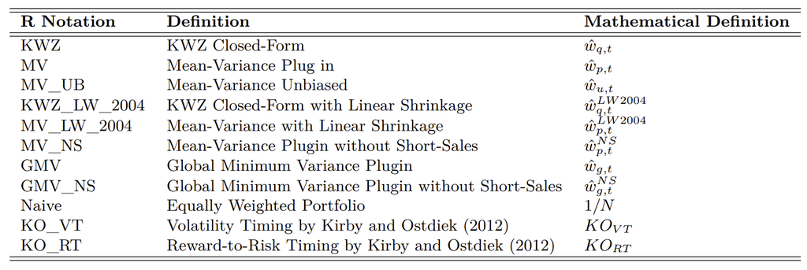

**Caption**: The above table defines the decision rules used in this article in line with the mathematical definitions from KWZ.

Note that as long as the function organizes the portfolio weights in a single list as above, the following backtesting procedure can be generalized to accommodate other decision rules and estimation methods.

# Backtesting

We can run the `DR_function` on a rolling basis to perform backtesting. Nonetheless, note that three main inputs are needed to reduplicate the performance results: 1. The risk aversion level denoted by $\gamma$ 2. Transactions cost denoted by `TC` 3. Sample size $T$

Similar to the baseline analysis from KWZ (see, e.g., Tables 1 and 2), I set

```r
gamma <- 3
TC <- 0/(100^2) # to reflect basis points
sample_size <- 120
```

In the following, I utilize the `DR_function` and write a single main function that takes the data index and the above three inputs to evaluate the decision rules in terms of out-of-sample returns.

**Personal Note:** It is worth mentioning that the function was not written directly. Instead, I started with a single data and a few commands, which were then generalized. This is probably the best practice of writing functions to avoid potential coding errors/issues.

```r
main_run_portfolio_fun <- function(choose_data,gamma,sample_size,TC) {

  # choose the data - in total we have six different sets
  ds <- ds_list[[choose_data]]
  months_tot <- sort(unique(ds$date))

  # store data
  results_all <- data.frame()

  # store portfolio weights - relevant for portfolio turnover and TC
  W_ALL_list <- list()

  # run a loop from T until the end-1 of data
  for(i in sample_size:(length(months_tot) - 1)) {

    # current month
    month_i <- months_tot[i]
    # next month, which is unknown during portfolio construction
    month_i_plus <- months_tot[i+1]

    # for tracking backtesting
    if( month(month_i_plus) == 12) {
      cat("this is month ", as.character(month_i_plus),"\n")
    }

    # define the in-sample data
    R_sub <- ds[ds$date <= month_i,]
    run_DR_fun <- DR_function(R_sub,gamma,sample_size,TC)


    # keep track of weights and stack in matrix
    W_1_list <- lapply(run_DR_fun,t)
    W_1_list <- lapply(W_1_list,function(x) data.frame(month_i_plus,x) )
    W_ALL_list <- c(W_ALL_list,list(W_1_list))

    R_next <- ds[ds$date == month_i_plus,-1]
    R_port <- lapply(W_1_list, function(x)  sum(x[,-1]*R_next)  )
    R_port2 <- data.frame(date = month_i_plus,Reduce(cbind,R_port))
    names(R_port2)[-1] <- names(R_port)
    results_all <- rbind(results_all,R_port2)
  }

  list(port_ret = results_all, weights = W_ALL_list)
}
```

The loop in the above function computes two main objects. The first one contains the out-of-sample portfolio returns `results_all`, whereas the other is a list of all portfolio weights over time denoted by `W_ALL_list`. Given the former, we can easily compute gross returns and other performance measures. For the latter, we can consider performance in terms of net transaction cost and other portfolio characteristics related to its stability (e.g., turnover) or diversification. As mentioned above, note that the function is generalized to evaluate multiple decision rules simultaneously by utilizing the `lapply` base function.

In the following, let us consider the gross returns and replicate some of the results of 2 from KWZ, which does not consider transactions cost. Specifically, Tables 1 and 2 from KWZ report the certainty equivalent returns (CER) and the Sharpe ratio for different decision rules (rows) and data sets (columns). In our case, we have eleven decision rules and six data sets. Given that the data is public, we should get identical results as the decision rules do not depend on a black box model or hidden validation that could result in additional degrees of freedom.

However, researchers should be aware of one issue with the Fama-French data. It appears that the same time series of factor returns changes over time due to ex-post adjustments in the construction of the factor. This issue has been raised by Akey, Robertson, and Simutin (2022), which the authors refer to as “Noisy Factors.” Specifically, the authors find that “factor returns differ substantially depending on when the data were downloaded, and only a small portion of these retroactive changes is explained by revisions in the underlying data.” Nonetheless, this issue should result in a slight difference given that KWZ was conducted post-2018.

To implement, I utilize `main_run_portfolio_fun` across all data sets and compute the time series returns of our decision rules in the following manner:

```r
run_experiment <- mclapply(1:length(ds_list),
                           function(data_index) main_run_portfolio_fun(data_index,gamma,sample_size,TC = 0),
                           mc.cores = detectCores() )
```

[output not shown]

Note that the above command runs the backtesting experiment across all data sets using three main inputs, specifying the risk aversion, sample size, and transactions cost. Given the portfolio returns from each data experiment, we can easily compute the certainty equivalent returns (CER) and Sharpe ratios (SR) for each portfolio-data specification:

```r
sr_fun <- function(x) round(mean(x)/sd(x),4)
cer_fun <- function(x) round(mean(x) - (gamma/2)*var(x),4)

port_ret_list <- lapply(run_experiment,function(x) x$port_ret)
MS_CER <- sapply(port_ret_list, function(x) apply(x[,-1],2,cer_fun))
MS_SR <- sapply(port_ret_list, function(x) apply(x[,-1],2,sr_fun))
```

For a consistent comparison, I copy the CER and the Sharpe ratios from Tables 1 and 2, respectively, of KWZ that correspond to the 6 data sets and the 11 decision rules studied in this article:

```r
Table1_KWZ <- "KWZ 0.0098 0.0102 0.0064 0.0060 0.0081 0.0259 0.0022 -0.0068
MV -0.0063 -0.0635 -0.0141 -0.0705 -0.0270 -1.2294 -0.3998 -27.0937
MV_UB -0.0013 -0.0284 -0.0075 -0.0361 -0.0147 -0.3039 -0.1278 -0.7464
KWZ_LW_2004 0.0120 0.0112 0.0100 0.0083 0.0100 0.0695 0.0042 0.0020
MV_LW_2004 0.0070 -0.0009 0.0048 -0.0219 0.0013 -0.0444 -0.1243 -0.5255
MV_NS 0.0060 0.0050 0.0028 0.0045 0.0048 0.0090 0.0003 0.0000
GMV 0.0051 0.0060 0.0020 0.0050 0.0050 0.0035 0.0025 -0.0056
GMV_NS 0.0035 0.0041 0.0041 0.0049 0.0025 0.0059 0.0042 0.0027
Naive 0.0026 0.0036 0.0022 0.0034 0.0022 0.0013 0.0039 0.0024
KO_VT 0.0036 0.0043 0.0041 0.0045 0.0030 0.0046 0.0049 0.0037
KO_RT 0.0047 0.0045 0.0034 0.0049 0.0046 0.0061 0.0038 0.0019"


Table2_KWZ <- "KWZ 0.2521 0.2479 0.2452 0.1916 0.2238 0.5778 0.1194 0.0234
MV 0.2375 0.1999 0.2387 0.1470 0.1896 0.5614 0.0610 -0.0482
MV_UB 0.2405 0.2069 0.2400 0.1534 0.1940 0.5648 0.0671 -0.0428
KWZ_LW_2004 0.2693 0.2838 0.2456 0.2312 0.2591 0.6925 0.1661 0.1093
MV_LW_2004 0.2545 0.2393 0.2383 0.1792 0.2118 0.6558 0.0728 -0.0138
MV_NS 0.1905 0.1734 0.1299 0.1644 0.1700 0.2495 0.0996 0.0943
GMV 0.1823 0.2085 0.1088 0.1813 0.1843 0.1478 0.1227 0.0369
GMV_NS 0.1450 0.1595 0.1639 0.1816 0.1236 0.2188 0.1717 0.1291
Naive 0.1276 0.1484 0.1224 0.1426 0.1209 0.1034 0.1527 0.1205
KO_VT 0.1466 0.1636 0.1619 0.1704 0.1338 0.1751 0.1902 0.1584
KO_RT 0.1695 0.1651 0.1438 0.1768 0.1665 0.2046 0.1534 0.1078"
```

To process in a readable format, I write the following function that takes the above content and loads it into a readable matrix

```r
read_table_fun <- function(KWZ_table) {
  x <- scan(textConnection(KWZ_table),what = character(),sep = "\n")
  x <- strsplit(x," ")
  x_names <- sapply(x,function(x) x[1] )
  X <- t(sapply(x,function(x) as.numeric(x[-1]) ))
  colnames(X) <- c("MOM10","BM25",  "IVOL", "OPIN25", "NMV16", "NMV46", "IND49","Stocks")
  # keep relevant data sets
  X <- X[,c("MOM10","BM25","OPIN25","NMV16","NMV46","IND49")]
  rownames(X) <- x_names
  KWZ_table <- X
  return(KWZ_table)
}

Table1_KWZ <- read_table_fun(Table1_KWZ)
```

```
Read 11 items
```

```r
Table2_KWZ <- read_table_fun(Table2_KWZ)
```

```
Read 11 items
```

As a summary, I plot my results versus those by KWZ using the `ggplot2` library. Let us summarize all results in a `data.frame` that is user-friendly to input into `ggplot`:

```r
ds_plot <- data.frame()
for (r in 1:nrow(MS_CER)) {
  ds_plot_r <- data.frame(KWZ = Table1_KWZ[r,], MS = MS_CER[r,],
                          Data = names(ds_list), Portfolio = rownames(MS_CER)[r] )
  ds_plot <- rbind(ds_plot,ds_plot_r)
}

# save data
ds_plot1 <- ds_plot
ds_plot1$Metric <- "CER"

ds_plot <- data.frame()
for (r in 1:nrow(MS_SR)) {
  ds_plot_r <- data.frame(KWZ = Table2_KWZ[r,], MS = MS_SR[r,],
                          Data = names(ds_list), Portfolio = rownames(MS_SR)[r] )
  ds_plot <- rbind(ds_plot,ds_plot_r)
}
ds_plot2 <- ds_plot
ds_plot2$Metric <- "SR"

# stack data altogether
ds_plot <- rbind(ds_plot1,ds_plot2)
```

## CER: Table 1

Now we are ready to plot the data. Since the CER and SR correspond to different performance metrics, we visualize each separately. For the CER, we have:

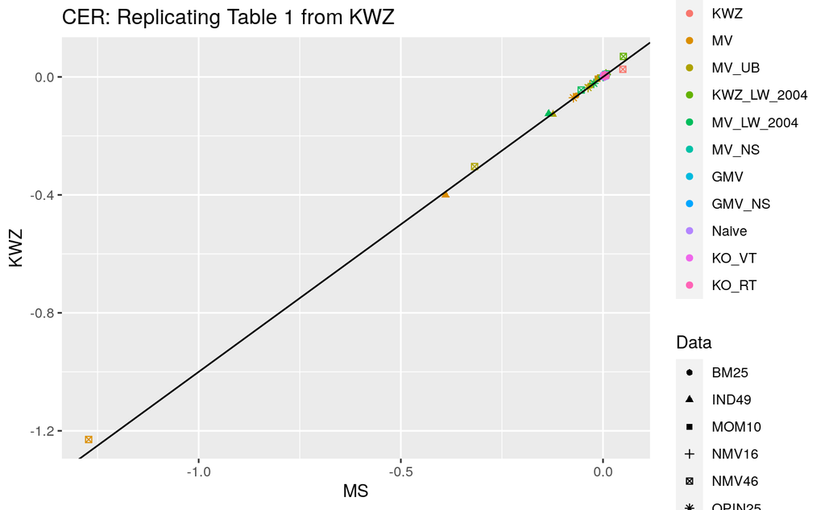

```r
p <- ggplot(ds_plot[ds_plot$Metric == "CER",], aes(y = KWZ, x = MS,colour = Portfolio,shape = Data))
p <- p + geom_point()
p <- p + geom_abline(slope = 1, intercept = 0)
p <- p + ggtitle("CER: Replicating Table 1 from KWZ")
p
```

Overall, the results seem consistent, with some slight variations in some cases. The most significant deviation comes from the MV decision rule, which also results in the worst performance. This is most evident in the NVM46 data set.

## SR: Table 2

Let us repeat the same plot for the or the SR:

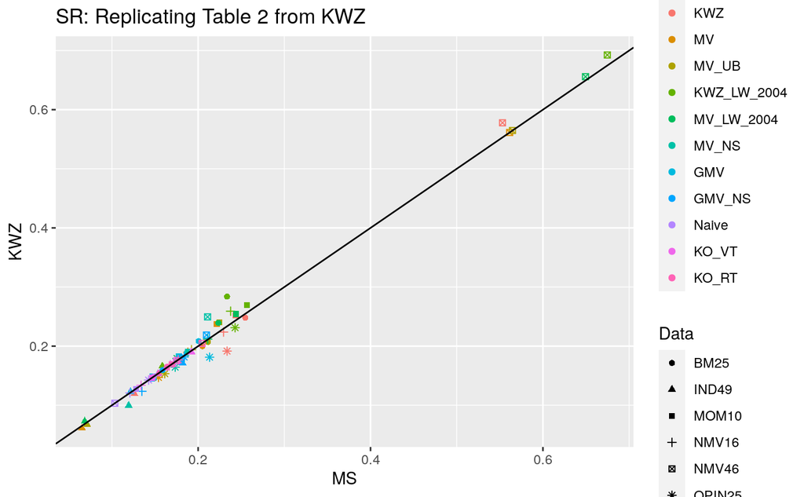

```r
p <- ggplot(ds_plot[ds_plot$Metric == "SR",], aes(y = KWZ, x = MS,colour = Portfolio,shape = Data))
p <- p + geom_point()
p <- p + geom_abline(slope = 1, intercept = 0)
p <- p + ggtitle("SR: Replicating Table 2 from KWZ")
p
```

We observe that most decision rules result in SR between 0 and 0.4, whereas in a few cases, the SR is greater than 0.5. This is mainly the case for the NMV46 data. Nonetheless, we observe a good consistency between the original findings by KWZ and ours. There are, however, a few slight deviations. We expect identical results for the MV, GMV, and Naive decision rules since we are using closed-form solutions, and there are no degrees of freedom for an error. For the short sales, there are some degrees of freedom in terms of initial weights and how the optimization algorithm used in R differs from the one used by KWZ, which could be built using different software. The same applies to shrinkage-based techniques.

Additionally, such deviations could be attributed to the fact that the Fama-French data is subjected to changes over time, as pointed out by Akey, Robertson, and Simutin (2022). To check the last point made above, let us focus on NMV16 and NMV46 data sets:

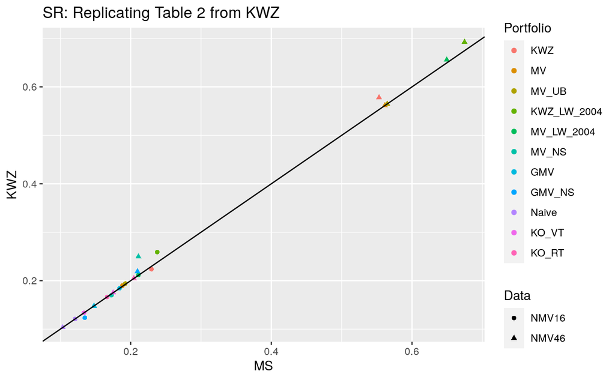

```r
ds_plot_NVM <- ds_plot[ds_plot$Data %in% c("NMV16","NMV46") & ds_plot$Metric == "SR",]
p <- ggplot(ds_plot_NVM, aes(y = KWZ, x = MS,colour = Portfolio,shape = Data))
p <- p + geom_point()
p <- p + geom_abline(slope = 1, intercept = 0)
p <- p + ggtitle("SR: Replicating Table 2 from KWZ")
p
```

As conjectured above, the closed-form solution portfolios are consistent with KWZ. However, we note a slight difference in the decision rules with no short sales, which requires numerical optimization. A similar observation follows when we compare the shrinkage-based techniques.

## Turnover: Table 3

Now, let us evaluate the portfolio turnover of each decision rule. To do so, I follow the same metric used by KWZ - see Equation (60) from the paper. The following nested loop computes the turnover across different data sources and decision rules:

```r
MS_TO <- c()
for (data_i in 1:length(ds_list)) {
  TO_vec <- c()
  for (decision_rule in rownames(MS_SR)) {
    W_list_data <- run_experiment[[data_i]]$weights
    W_list_data_DR <- lapply(W_list_data, function(x) data.frame(x[names(x) %in% decision_rule]) )
    W_mat <- Reduce(rbind,W_list_data_DR)
    R_mat <- ds_list[[data_i]]
    W_mat <- W_mat[-nrow(W_mat),]
    R_mat <- R_mat[R_mat$date %in% W_mat[,1],]
    W_mat_adj <- W_mat[,-1]*(1 + R_mat[,-1])
    W_mat_adj <- t(apply(W_mat_adj,1,function(x) x/sum(x))) # adjust positions to equal one
    TO <- W_mat[-1,-1] - W_mat_adj[-nrow(W_mat_adj),]
    TO <- apply(TO,1,function(x) sum(abs(x)) )
    TO_mean <- mean(TO)
    TO_vec <- c(TO_vec,TO_mean)
  }
  MS_TO <- cbind(MS_TO,TO_vec)
}
rownames(MS_TO) <- rownames(MS_SR)
colnames(MS_TO) <- names(ds_list)
```

The above code takes into consideration that positions do change over time. For instance, one may conjecture that the naive portfolio has zero turnover since its weights are constant over time; however, this is not the case. Its positive turnover comes mainly from the fact that the portfolio is re-balanced each month to maintain equal weights after considering the gross returns and, hence, changes in the portfolio position. To better understand how it is computed, consider the following example:

```r
d <- 5
W_1 <- rep(1/d,d)
W_1_adj <- W_1*(1+rnorm(d,0,0.06))
W_2 <- W_1
rbind(W_1_adj,W_2)
```

```
             [,1]      [,2]      [,3]      [,4]      [,5]
W_1_adj 0.2119116 0.1857479 0.1863003 0.1977841 0.2065548
W_2     0.2000000 0.2000000 0.2000000 0.2000000 0.2000000
```

As returns are realized, the initial positions change as well. In order to bring back to equal weights, the portfolio manager needs to re-balance, resulting in a turnover of

```r
sum(abs(W_2 - W_1_adj))
```

```
[1] 0.04863401
```

The operations of this simple example are conducted for each month, but as a summary, it is common to report the average over time. This is done for all data sets and decision rules.

For a consistent comparison, I collect the data from KWZ (Table 3):

```r
Table3_KWZ <- "KWZ 2.0157 3.5212 2.9934 1.9283 2.8730 34.0907 1.2583 3.8888
MV 5.0765 54.3620 7.1199 16.3314 11.2294 434.8788 91.2610 1275.5124
MV_UB 4.3229 14.5806 6.5314 9.7989 8.6225 152.8220 40.1044 224.0102
KWZ_LW_2004 1.0061 1.2745 1.0879 1.1136 0.9959 5.2506 0.5241 0.6093
MV_LW_2004 2.4207 6.6031 2.6552 7.2740 3.5400 50.8673 15.2265 212.4453
MV_NS 0.1066 0.2393 0.1808 0.1945 0.1456 0.0558 0.2092 0.2648
GMV 0.2770 0.7665 0.2640 0.5413 0.4911 1.5337 0.8227 3.7827
GMV_NS 0.0817 0.0691 0.0088 0.0774 0.0559 0.0375 0.0733 0.1440
Naive 0.0176 0.0182 0.0172 0.0199 0.0197 0.0227 0.0341 0.0648
KO_VT 0.0281 0.0309 0.0188 0.0353 0.0347 0.0373 0.0481 0.0706
KO_RT 0.0746 0.0767 0.0886 0.1086 0.0959 0.0832 0.1369 0.1591"

Table3_KWZ <- read_table_fun(Table3_KWZ)
```

```
Read 11 items
```

Same as before let us organize the results in a user-friendly data frame that we can input efficiently into `ggplot`:

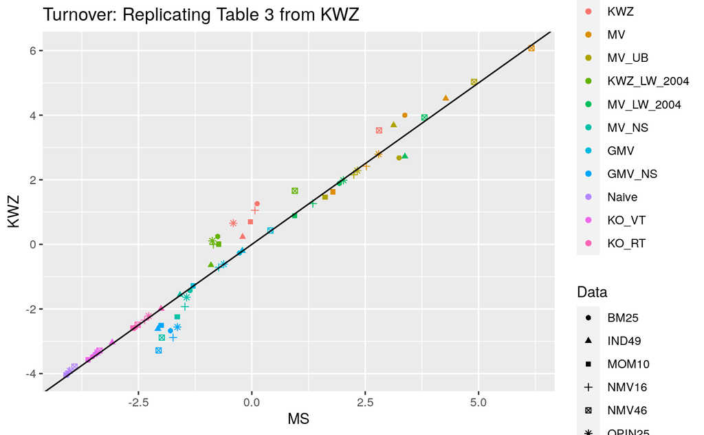

```r
ds_plot_TO <- data.frame()
for (r in 1:nrow(MS_TO)) {
  ds_plot_r <- data.frame(KWZ = Table3_KWZ[r,], MS = MS_TO[r,],
                          Data = names(ds_list), Portfolio = rownames(MS_TO)[r] )
  ds_plot_TO <- rbind(ds_plot_TO,ds_plot_r)
}

ds_plot_TO$KWZ <- log(ds_plot_TO$KWZ)
ds_plot_TO$MS <- log(ds_plot_TO$MS)

p <- ggplot(ds_plot_TO, aes(y = KWZ, x = MS,colour = Portfolio,shape = Data))
p <- p + geom_point()
p <- p + geom_abline(slope = 1, intercept = 0)
p <- p + ggtitle("Turnover: Replicating Table 3 from KWZ")
p
```

Note that I use the log scale to control for fixed effects associated with data and decision rules. For instance, the MV decision rule exhibits huge unrealistic positions. This evidence is consistent with the previous literature on estimation error in portfolio selection. Overall, we find consistent results with KWZ. The major flags stem from those with short sales constraints. To check the sensitivity with respect to the Fama-French data, let us repeat the same exercise as we did with the SR results, where we keep the NMV16 and NMV46 data sets:

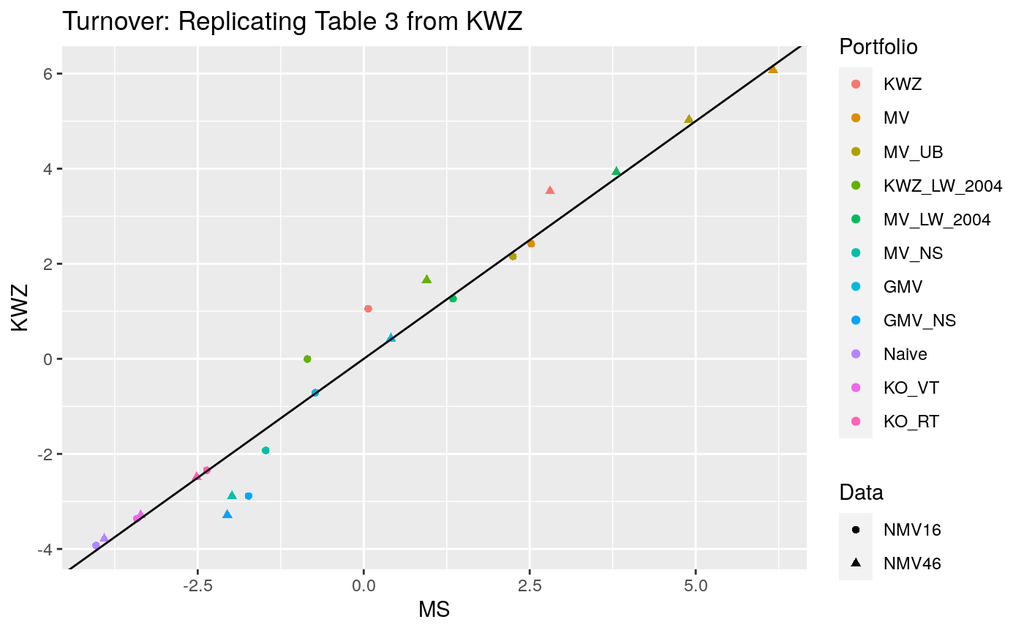

```r
ds_plot_TO_sub <- ds_plot_TO[ds_plot_TO$Data %in% c("NMV16","NMV46"),]
p <- ggplot(ds_plot_TO_sub, aes(y = KWZ, x = MS,colour = Portfolio,shape = Data))
p <- p + geom_point()
p <- p + geom_abline(slope = 1, intercept = 0)
p <- p + ggtitle("Turnover: Replicating Table 3 from KWZ")
p
```

Interestingly, we still witness slight variations; however, our results seem consistent overall with KWZ. Similar to the Sharpe ratio performance results, we note that these deviations mainly stem from the rules that depend on numerical optimization or rely on non-base R packages.

# Concluding Remarks

This article is designed to help future researchers to evaluate different portfolio rules easily and encourage reproducible research in portfolio selection. The paper by KWZ sets an excellent ground to attain this goal. While the analysis here covers a subset of the tests/results by the authors, the above empirical analysis covers standard benchmarks that future researchers should take into consideration in their “pursuit of the perfect portfolio.” Overall, the article finds consistent results with the original research, despite potential differences in the software. Such differences may also be attributed to the time lapse since the empirical analysis by KWZ was conducted, which goes to the “noisy factors” argument by Akey, Robertson, and Simutin (2022). Another critical part that needs to be taken into account is statistical significance. It is common to utilize a bootstrap methodology to determine whether one rule significantly outperforms another. I leave this for future examination.

# References

1. Akey, P., Robertson, A., & Simutin, M. (2022). Noisy factors. Rotman School of Management Working Paper Forthcoming.
2. Kan, R., Wang, X., & Zhou, G. (2022). Optimal portfolio choice with estimation risk: No risk-free asset case. Management Science, 68(3), 2047-2068.
3. Kirby, C., & Ostdiek, B. (2012). It’s all in the timing: simple active portfolio strategies that outperform naive diversification. Journal of Financial and Quantitative Analysis, 47(2), 437-467.
4. Novy-Marx, R., & Velikov, M. (2016). A taxonomy of anomalies and their trading costs. The Review of Financial Studies, 29(1), 104-147.